# act_report

## Report: act_report

- Create a **250-word-minimum written report** called "act_report.pdf" or "act_report.html" that communicates the insights and displays the visualization(s) produced from your wrangled data. This is to be framed as an external document, like a blog post or magazine article, for example.

### Insights

```python
import matplotlib.pyplot as plt
%matplotlib inline
```

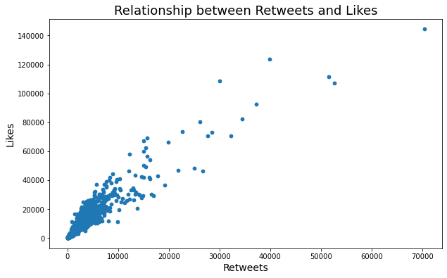

```python
import pandas as pd
twitter_archive_master = pd.read_csv('C:/Users/Rasheed Lawal/Downloads/twitter_archive_master.csv')
twitter_archive_master.plot(x = "retweet_count", y = "favorite_count", kind ='scatter', figsize=(10,6))
plt.title('Relationship between Retweets and Likes', fontsize=18)
plt.xlabel('Retweets', fontsize=14)
plt.ylabel('Likes', fontsize=14);
```

1. The doggo,puppo dog stage had the most number of likes with about 41 thousand likes from the bar chart shown. If in any case the @WeRateDogs wants to gather more engagements on his tweet, he should post more on doggo,puppo to be able to gather more likes.

```python
twitter_archive_master.groupby('dog_stage')['favorite_count'].mean().sort_values(ascending=False)
```

```
dog_stage
doggo,puppo      41835.000000
puppo            19518.363636
doggo            17547.403226
doggo,floofer    14816.000000
doggo,pupper     12005.888889
floofer          11188.428571
None              7293.989778
pupper            6186.216749
Name: favorite_count, dtype: float64
```

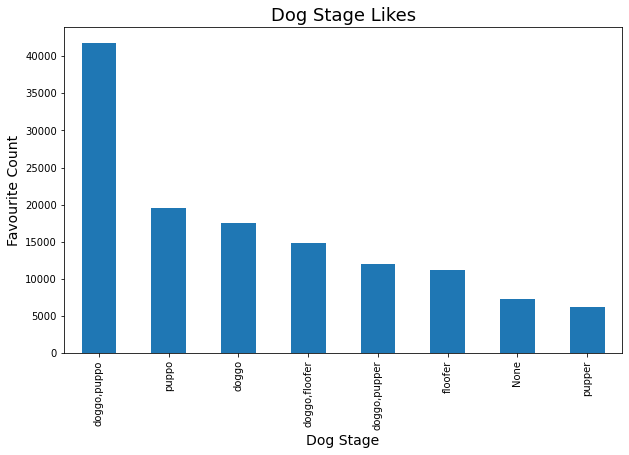

```python
twitter_archive_master.groupby('dog_stage')['favorite_count'].mean().sort_values(ascending=False).plot(kind='bar', figsize=(10,6))
plt.title('Dog Stage Likes', fontsize=18)
plt.ylabel('Favourite Count', fontsize=14)
plt.xlabel('Dog Stage', fontsize=14);
```

1. A majority of tweets made by @WeRateDogs were tweeted from an iPhone as illustrated in the bar chart below.

```python
twitter_archive_master.source.value_counts()
```

```
Twitter for iPhone    3860
Twitter Web Client      56
TweetDeck               20
Name: source, dtype: int64
```

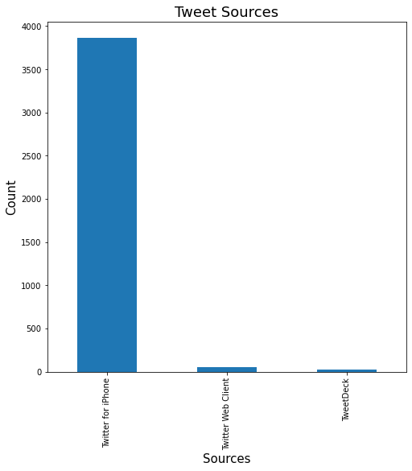

```python
twitter_archive_master['source'].value_counts().plot(kind='bar', figsize=(8,8))
plt.title('Tweet Sources', fontsize=18)
plt.ylabel('Count', fontsize=15)
plt.xlabel('Sources', fontsize=15);
```

### Limitations

1. Correlation between retweets and likes can only be inferred and not causation.
2. Inability to retrieve the tweet status of some tweets while querying the data.
3. The elimination of a tweet source - 'Vine - Make a Scene', as the analysis is a representative of a short sample.